# First Time Buyers

## 0.1 Scope

This document describes the scoring and subsequent segmentation of First Time Buyers (FTB). The scoring is a “forward-looking” measure, i.e., it’s the propensity that the Buyer will convert in the next 90-days. The scoring is performend using a “Cox Proporsional Hazards” model. The resulting segmentation can be used for customized marketing inititiatives.

## 0.2 Libraries

```r
library(knitr)
library(survival)
library(rpart)
library(dplyr)
source("db.R")
```

## 0.3 Data

The table mart_ftb is a data mart designed for this project. It contains all first time orders since 01/01/2018.

```r
# Read Data
query <- 'select * from mart_ftb'
data <- exeQueryString (query, stringsAsFactors = TRUE)
```

We define the data used for training our model and the data corresponding to first time customers that have not placed a second order yet.

```r
data.train <- data
data.score <- data[!is.na(data$IS_SCORE),]
data.nm    <- data[!is.na(data$NET_MARGIN_FWD_90D),]
```

## 0.4 Time-to-Event Modeling

### 0.4.1 Survival Object

We fit the survival model. The column OUTCOME_TIME is the time between the first purchase and the subsequent event. The OUTCOME_CENSORED is a binary column indicating whether the second purchase has happened.

```r
surv <- Surv(time = data.train$OUTCOME_TIME,
            event = data.train$OUTCOME_CENSORED)
```

### 0.4.2 Cox Proportional Hazards model

Fit the Cox proportional hazards model. We use a limited set of attributes to enhance the predictive power of the model.

```r
cox <- coxph(surv ~ QUARTER +
                    NEW_CHANNEL +
                    USERGROUP_V2 +
                    TIME_BETWEEN_REG_FIRST, data = data.train)
cox
```

```
## Call:
## coxph(formula = surv ~ QUARTER + NEW_CHANNEL + USERGROUP_V2 +
##     TIME_BETWEEN_REG_FIRST, data = data.train)
##
##                                  coef  exp(coef)   se(coef)       z        p
## QUARTERQ2                   6.820e-02  1.071e+00  7.392e-03   9.227  < 2e-16
## QUARTERQ3                   8.578e-02  1.090e+00  7.297e-03  11.755  < 2e-16
## QUARTERQ4                   1.005e-01  1.106e+00  6.503e-03  15.457  < 2e-16
## NEW_CHANNELFed Gov Clients -1.551e-02  9.846e-01  1.782e-02  -0.871   0.3840
## NEW_CHANNELFed Gov Direct  -1.445e-02  9.857e-01  8.197e-03  -1.763   0.0779
## NEW_CHANNELNew Business     9.184e-02  1.096e+00  1.844e-02   4.980 6.36e-07
## NEW_CHANNELPPC Select      -2.592e-01  7.716e-01  3.604e-02  -7.194 6.30e-13
## NEW_CHANNELTerminated      -2.779e-02  9.726e-01  1.351e-02  -2.056   0.0397
## USERGROUP_V2IS_NOT_LEVI    -1.312e-01  8.770e-01  5.584e-03 -23.496  < 2e-16
## TIME_BETWEEN_REG_FIRST     -2.538e-04  9.997e-01  5.599e-06 -45.335  < 2e-16
##
## Likelihood ratio test=3813  on 10 df, p=< 2.2e-16
## n= 285891, number of events= 180869
##    (6760 observations deleted due to missingness)
```

Using the fitted model we can predict the propensity of the Buyer converting in a given time period. First we calculate the cumulative baseline hazard function.

```r
curve <- basehaz(cox, centered=TRUE); names(curve) <- c("chaz", "time")
head(curve)
```

```
##         chaz time
## 1 0.03761925    0
## 2 0.06535878    1
## 3 0.08409388    2
## 4 0.10027852    3
## 5 0.11456970    4
## 6 0.12716503    5
```

Then we calculate the baseline 30, 60 and 90 day conversion propensity.

```r
curve            <- basehaz(cox, centered=TRUE); names(curve) <- c("chaz", "time")
curve$haz        <- c(curve$chaz[1], diff(curve$chaz))
curve$conv_30    <- 1 - exp(-lead(curve$chaz, 30)) - (1 - exp(-lead(curve$chaz, 0)))
curve$conv_60    <- 1 - exp(-lead(curve$chaz, 60)) - (1 - exp(-lead(curve$chaz, 0)))
curve$conv_90    <- 1 - exp(-lead(curve$chaz, 90)) - (1 - exp(-lead(curve$chaz, 0)))
conversion <- function(time)
{
   if (time > 1000) (return (0.007422))
   i = which(curve$time == time)
   return(curve[i,]$conv_90)
}
head(curve)
```

```
##         chaz time        haz   conv_30   conv_60   conv_90
## 1 0.03761925    0 0.03761925 0.2140559 0.2815446 0.3315429
## 2 0.06535878    1 0.02773953 0.1905507 0.2569427 0.3067819
## 3 0.08409388    2 0.01873510 0.1759313 0.2413285 0.2908630
## 4 0.10027852    3 0.01618464 0.1638944 0.2286838 0.2773962
## 5 0.11456970    4 0.01429118 0.1537048 0.2177771 0.2659090
## 6 0.12716503    5 0.01259533 0.1453644 0.2082827 0.2562435
```

Now we can use the baseline conversion to calculate the actual 90-day conversion propensity for each Buyer.

```r
data.score$baseline_hazard <- sapply(data.score$OUTCOME_TIME, conversion)
data.score$risk            <- predict(cox, newdata = data.score, type = 'risk')
data.score$score           <- data.score$baseline_hazard * data.score$risk
```

### 0.4.3 Predicting the Net Margin

Predict the expected Net Margin per Buyer. We fit a linear regression model on the Net Margin of FTBs.

```r
linearMod <- lm(NET_MARGIN_FWD_90D ~ QUARTER +
                                     NEW_CHANNEL +
                                     USERGROUP_V2 +
                                     TIME_BETWEEN_REG_FIRST, data = data.nm)
data.score$nm <- predict(linearMod, newdata = data.score)
data.score$nm_pred <- data.score$score * data.score$nm
```

In this section we calculated two Buyer scores: (i) A propensity score for converting in the next 90-days, and (ii) the expected Net Margin. We will use the latter to propose a Buyer and a Client segmentation.

## 0.5 Segments

### 0.5.1 Buyers

We segment the Buyers using a segmentation technique based on recursive partitioning. The technique suggests three segments.

```r
data.score     <- data.score[order(data.score$nm_pred),]
data.score$rnk <- 1:nrow(data.score)
fit <- rpart(formula = score ~ rnk,
                data = data.score,
             control = rpart.control(cp = 0.075),
              method = "anova"
)
fit
```

```
## n=105022 (4295 observations deleted due to missingness)
##
## node), split, n, deviance, yval
##       * denotes terminal node
##
## 1) root 105022 223.207800 0.04005888
##   2) rnk< 64514.5 64514   5.188569 0.01149354 *
##   3) rnk>=64514.5 40508  81.538240 0.08555271
##     6) rnk< 98643.5 34129  12.452860 0.07068064 *
##     7) rnk>=98643.5 6379  21.150140 0.16512150 *
```

```r
i <- 63189; data.score[i,]$nm_pred;
```

```
## [1] 19.26649
```

```r
i <- 98325; data.score[i,]$nm_pred;
```

```
## [1] 57.34973
```

```r
tags <- c("1","2", "3")
breaks <- c(0, 20.79, 57.44, 10000)
data.score$bins <- cut(data.score$nm_pred,
                       breaks=breaks,
                       include.lowest=TRUE,
                       right=FALSE,
                       labels=tags
)
data.score <- data.score[!is.na(data.score$nm_pred),]
aggregate(data.score$nm_pred, by=list(data.score$bins), FUN=mean)
```

```
##   Group.1        x
## 1       1  5.54938
## 2       2 33.06186
## 3       3 88.99016
```

```r
aggregate(data.score$nm_pred, by=list(data.score$bins), FUN=sum)
```

```
##   Group.1         x
## 1       1  357346.8
## 2       2 1122979.0
## 3       3  592852.4
```

```r
t <- aggregate(data.score$nm_pred, by=list(data.score$bins), FUN=length)
t
```

```
##   Group.1     x
## 1       1 64394
## 2       2 33966
## 3       3  6662
```

```r
t$x/sum(t$x)
```

```
## [1] 0.61314772 0.32341795 0.06343433
```

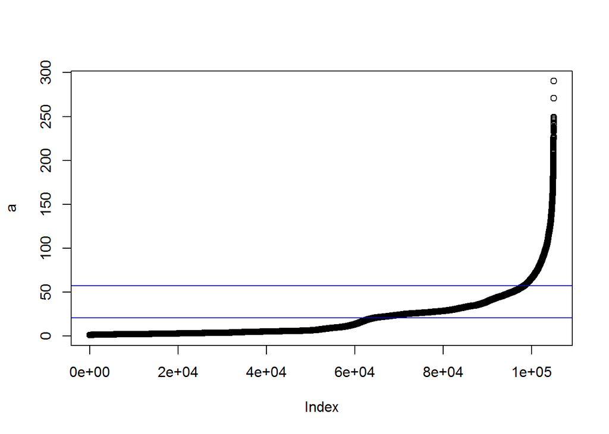

```r
a <- sort(data.score$nm_pred); plot(a)
abline(h = 20.79, col="blue")
abline(h = 57.44, col="blue")
```

### 0.5.2 Clients

We can use the Buyer score to create Client segments. In a similar fashion as before, we use a recursive partitioning technique to create a set of client segments

```r
library(rpart)
data.score$CLIENT_ID <- as.factor(data.score$CLIENT_ID)

fit <- rpart(score ~ CLIENT_ID,
             data   = data.score,
             method = "anova"
)

data.score$client_group <- predict(fit, data.score)
```

## 0.6 Export to the Database

The scores are attached to the data.score frame. The frame is written back to RPTMT.

```r
exp <- data.score[, c("CUSTOMER_ID", "CLIENT_ID", "score", "nm_pred", "bins", "client_group")]

# Output data
#con <- openCon()
#sqlDrop(channel = con,
#        sqtable = "mart_ftb_score",
#        errors = FALSE)
#sqlSave(channel = con,
#        dat =exp,
#        tablename = "mart_ftb_score",
#        append   = FALSE,
#        rownames = FALSE,
#        colnames = FALSE,
#        verbose  = FALSE,
#        safer    = TRUE,
#        addPK    = FALSE,
#        fast     = TRUE,
#        test     = FALSE,
#        nastring = NULL
#        )
#close(con)
```

## 0.7 Model Validation

```r
query <- 'select * from mart_ftb_test'
data.test <- exeQueryString (query, stringsAsFactors = TRUE)

data.test$baseline_hazard <- sapply(data.test$TEST_TIME, conversion)
data.test$risk            <- predict(cox, newdata = data.test, type = 'risk')
data.test$score           <- data.test$baseline_hazard * data.test$risk

data.test$nm <- predict(linearMod, newdata = data.test)
data.test$nm_pred <- data.test$score * data.test$nm

data.test$validation <- ifelse(!is.na(data.test$TEST_DAYS_TO_EVENT) & data.test$TEST_DAYS_TO_EVENT <= 90, 1, 0)

breaks <- seq(0, 1, 0.05)
data.test$score_bins <- cut(data.test$score,
                            breaks=breaks,
                            include.lowest=TRUE,
                            right=FALSE
                            #labels=tags
                            )

aggregate(data.test$validation, by=list(data.test$score_bins), FUN=mean)
```

```
##      Group.1         x
## 1   [0,0.05) 0.0426931
## 2 [0.05,0.1) 0.0992126
## 3 [0.1,0.15) 0.1354335
## 4 [0.15,0.2) 0.1817550
## 5 [0.2,0.25) 0.2296748
## 6 [0.25,0.3) 0.2787524
## 7 [0.3,0.35) 0.3223684
## 8 [0.35,0.4) 0.4000000
```